# CGDA - Case Study 2 - Analyze Phase

2023-04-10

# Analyze Data

## Load Packages

First we’ll load in packages for the processing phase.

- tidyverse: a collection of data analysis packages
- skimr: provides summary statistics

```r
library(tidyverse)
library(skimr)
```

## Load CSV Files

We’ll load the CSV files into separate data frames for analysis. We’ll also set any ordered factors.

```r
df_daily <- read_csv("daily.csv", col_types=cols(id=col_character(), date = col_date(format="%Y-%m-%d"), cs_id=col_character()))
df_daily$cs_id <- ordered(df_daily$cs_id, levels=c('1', '2', '3', '4', '5', '6', '7', '8', '9', '10', '11', '12', '13', '14', '15', '16', '17', '18', '19', '20', '21', '22', '23', '24', '25', '26', '27', '28', '29', '30', '31', '32', '33'))
df_hourly <- read_csv("hourly.csv", col_types=cols(id=col_character(), date_time = col_datetime(format="%Y-%m-%d %H:%M:%S"),date = col_date(format="%Y-%m-%d")))
df_hourly$cs_id <- ordered(df_hourly$cs_id, levels=c('1', '2', '3', '4', '5', '6', '7', '8', '9', '10', '11', '12', '13', '14', '15', '16', '17', '18', '19', '20', '21', '22', '23', '24', '25', '26', '27', '28', '29', '30', '31', '32', '33'))
df_minutes <- read_csv("minutes.csv", col_types=cols(id=col_character(), date_time = col_datetime(format="%Y-%m-%d %H:%M:%S")))
df_minutes$cs_id <- ordered(df_minutes$cs_id, levels=c('1', '2', '3', '4', '5', '6', '7', '8', '9', '10', '11', '12', '13', '14', '15', '16', '17', '18', '19', '20', '21', '22', '23', '24', '25', '26', '27', '28', '29', '30', '31', '32', '33'))
df_sleep_daily <- read_csv("sleep_daily.csv",col_types=cols(id=col_character(), date = col_date(format="%Y-%m-%d")))
df_sleep_daily$cs_id <- ordered(df_sleep_daily$cs_id, levels=c('1', '2', '3', '4', '5', '6', '7', '8', '9', '10', '11', '12', '13', '14', '15', '16', '17', '18', '19', '20', '21', '22', '23', '24', '25', '26', '27', '28', '29', '30', '31', '32', '33'))
df_sleep_minutes <- read_csv("sleep_minutes.csv", col_types=cols(id=col_character(), date_time = col_datetime(format="%Y-%m-%d %H:%M:%S")))
```

## Analyze Daily Data

We’ll start by analyzing the daily data. First we’ll take a look at the data structure, then we’ll plot a few items based on the available data.

### Inspect and Summarize Daily Data

```r
str(df_daily)
```

```
## spc_tbl_ [940 × 17] (S3: spec_tbl_df/tbl_df/tbl/data.frame)
##  $ id                        : chr [1:940] "1503960366" "1503960366" "1503960366" "1503960366" ...
##  $ date                      : Date[1:940], format: "2016-04-12" "2016-04-13" ...
##  $ weekday                   : chr [1:940] "Tuesday" "Wednesday" "Thursday" "Friday" ...
##  $ total_steps               : num [1:940] 13162 10735 10460 9762 12669 ...
##  $ total_distance            : num [1:940] 8.5 6.97 6.74 6.28 8.16 ...
##  $ tracker_distance          : num [1:940] 8.5 6.97 6.74 6.28 8.16 ...
##  $ logged_activities_distance: num [1:940] 0 0 0 0 0 0 0 0 0 0 ...
##  $ very_active_distance      : num [1:940] 1.88 1.57 2.44 2.14 2.71 ...
##  $ moderately_active_distance: num [1:940] 0.55 0.69 0.4 1.26 0.41 ...
##  $ light_active_distance     : num [1:940] 6.06 4.71 3.91 2.83 5.04 ...
##  $ sedentary_active_distance : num [1:940] 0 0 0 0 0 0 0 0 0 0 ...
##  $ very_active_minutes       : num [1:940] 25 21 30 29 36 38 42 50 28 19 ...
##  $ fairly_active_minutes     : num [1:940] 13 19 11 34 10 20 16 31 12 8 ...
##  $ lightly_active_minutes    : num [1:940] 328 217 181 209 221 164 233 264 205 211 ...
##  $ sedentary_minutes         : num [1:940] 728 776 1218 726 773 ...
##  $ calories                  : num [1:940] 1985 1797 1776 1745 1863 ...
##  $ cs_id                     : Ord.factor w/ 33 levels "1"<"2"<"3"<"4"<..: 1 1 1 1 1 1 1 1 1 1 ...
##  - attr(*, "spec")=
##   .. cols(
##   ..   id = col_character(),
##   ..   date = col_date(format = "%Y-%m-%d"),
##   ..   weekday = col_character(),
##   ..   total_steps = col_double(),
##   ..   total_distance = col_double(),
##   ..   tracker_distance = col_double(),
##   ..   logged_activities_distance = col_double(),
##   ..   very_active_distance = col_double(),
##   ..   moderately_active_distance = col_double(),
##   ..   light_active_distance = col_double(),
##   ..   sedentary_active_distance = col_double(),
##   ..   very_active_minutes = col_double(),
##   ..   fairly_active_minutes = col_double(),
##   ..   lightly_active_minutes = col_double(),
##   ..   sedentary_minutes = col_double(),
##   ..   calories = col_double(),
##   ..   cs_id = col_character()
##   .. )
##  - attr(*, "problems")=<externalptr>
```

```r
summary(df_daily)
```

```
##       id                 date              weekday           total_steps
##  Length:940         Min.   :2016-04-12   Length:940         Min.   :    0
##  Class :character   1st Qu.:2016-04-19   Class :character   1st Qu.: 3790
##  Mode  :character   Median :2016-04-26   Mode  :character   Median : 7406
##                     Mean   :2016-04-26                      Mean   : 7638
##                     3rd Qu.:2016-05-04                      3rd Qu.:10727
##                     Max.   :2016-05-12                      Max.   :36019
##
##  total_distance   tracker_distance logged_activities_distance
##  Min.   : 0.000   Min.   : 0.000   Min.   :0.0000
##  1st Qu.: 2.620   1st Qu.: 2.620   1st Qu.:0.0000
##  Median : 5.245   Median : 5.245   Median :0.0000
##  Mean   : 5.490   Mean   : 5.475   Mean   :0.1082
##  3rd Qu.: 7.713   3rd Qu.: 7.710   3rd Qu.:0.0000
##  Max.   :28.030   Max.   :28.030   Max.   :4.9421
##
##  very_active_distance moderately_active_distance light_active_distance
##  Min.   : 0.000       Min.   :0.0000             Min.   : 0.000
##  1st Qu.: 0.000       1st Qu.:0.0000             1st Qu.: 1.945
##  Median : 0.210       Median :0.2400             Median : 3.365
##  Mean   : 1.503       Mean   :0.5675             Mean   : 3.341
##  3rd Qu.: 2.053       3rd Qu.:0.8000             3rd Qu.: 4.782
##  Max.   :21.920       Max.   :6.4800             Max.   :10.710
##
##  sedentary_active_distance very_active_minutes fairly_active_minutes
##  Min.   :0.000000          Min.   :  0.00      Min.   :  0.00
##  1st Qu.:0.000000          1st Qu.:  0.00      1st Qu.:  0.00
##  Median :0.000000          Median :  4.00      Median :  6.00
##  Mean   :0.001606          Mean   : 21.16      Mean   : 13.56
##  3rd Qu.:0.000000          3rd Qu.: 32.00      3rd Qu.: 19.00
##  Max.   :0.110000          Max.   :210.00      Max.   :143.00
##
##  lightly_active_minutes sedentary_minutes    calories        cs_id
##  Min.   :  0.0          Min.   :   0.0    Min.   :   0   1      : 31
##  1st Qu.:127.0          1st Qu.: 729.8    1st Qu.:1828   2      : 31
##  Median :199.0          Median :1057.5    Median :2134   4      : 31
##  Mean   :192.8          Mean   : 991.2    Mean   :2304   5      : 31
##  3rd Qu.:264.0          3rd Qu.:1229.5    3rd Qu.:2793   6      : 31
##  Max.   :518.0          Max.   :1440.0    Max.   :4900   7      : 31
##                                                          (Other):754
```

### Plot Daily Data

While it is intriguing to analyze collected data for health or statistical correlation, we must remember that the goal is to identify trends in usage of the devices. It is easy to become distracted with creating many graphs that may not help solve the business task. We are going to focus on analyzing the usage of the devices to see if we can develop relevant insights.

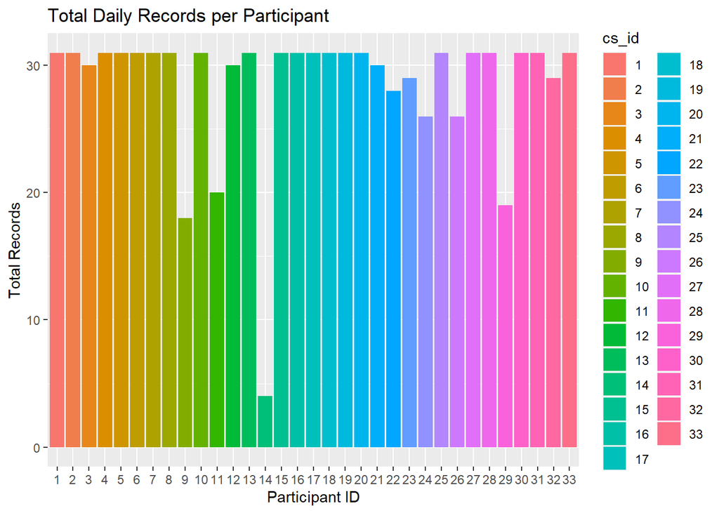

```r
# Total records by id
df_daily %>%
  group_by(cs_id) %>%
  summarize(total_records = n()) %>%
  ggplot(aes(x=cs_id, y=total_records, fill=cs_id)) + geom_col() + scale_fill_discrete() + labs(title="Total Daily Records per Participant") + xlab("Participant ID") + ylab("Total Records")
```

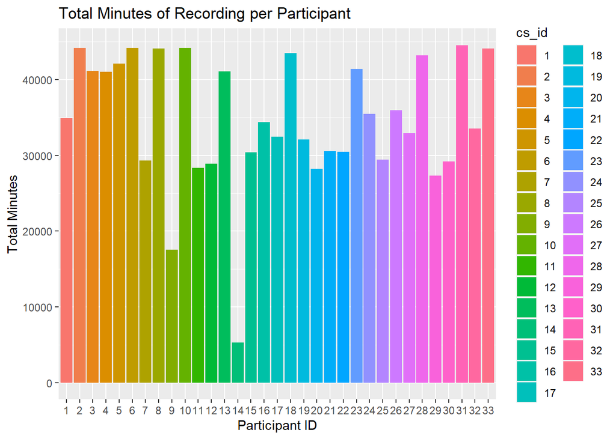

```r
# Total minutes of recording by id
# there are 43,200 minutes in 30 days
df_daily %>%
  group_by(cs_id) %>%
  summarize(total_minutes = sum(very_active_minutes, fairly_active_minutes, lightly_active_minutes, sedentary_minutes)) %>%
  ggplot(aes(x=cs_id, y=total_minutes, fill=cs_id)) + geom_col() + scale_fill_discrete() + labs(title="Total Minutes of Recording per Participant") + xlab("Participant ID") + ylab("Total Minutes")
```

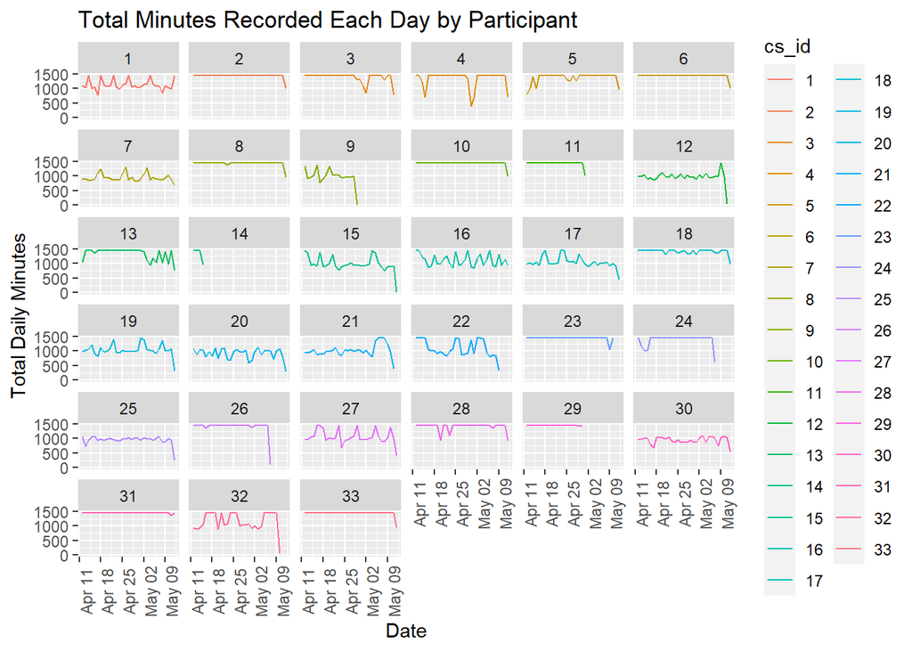

```r
# Total minutes recorded each day, line = id
# there are 1,440 minutes in 1 day
df_daily %>%
  rowwise() %>%
  mutate(daily_minutes = sum(very_active_minutes, fairly_active_minutes, lightly_active_minutes, sedentary_minutes)) %>%
  ggplot(aes(x=date, y=daily_minutes, color=cs_id)) + geom_line() + facet_wrap(~cs_id) + scale_color_discrete() + theme(axis.text.x = element_text(angle=90)) + labs(title="Total Minutes Recorded Each Day by Participant") + xlab("Date") + ylab("Total Daily Minutes")
```

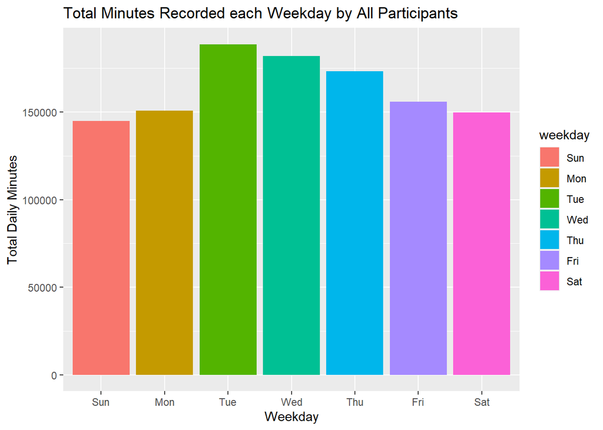

```r
# Total minutes recorded each day, by weekday
df_daily %>%
  mutate(weekday = wday(date, label=TRUE)) %>%
  group_by(weekday) %>%
  summarise(total_minutes = sum(very_active_minutes, fairly_active_minutes, lightly_active_minutes, sedentary_minutes)) %>%
  ggplot(aes(x=weekday, y=total_minutes, fill=weekday)) + geom_col() + scale_fill_discrete() + labs(title="Total Minutes Recorded each Weekday by All Participants") + xlab("Weekday") + ylab("Total Daily Minutes")
```

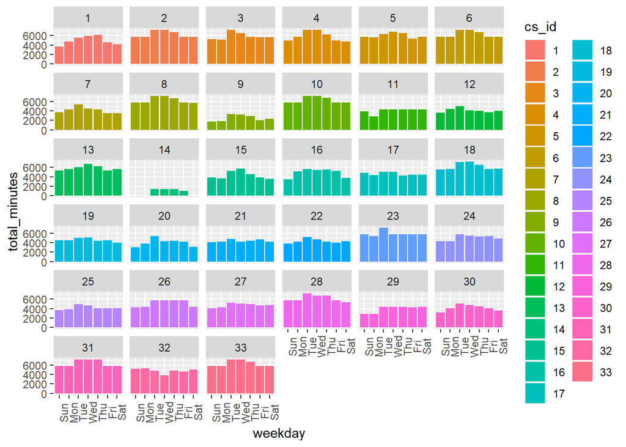

```r
# Total minutes recorded each weekday, by id
df_daily %>%
  mutate(weekday = wday(date, label=TRUE)) %>%
  group_by(cs_id, weekday) %>%
  summarise(total_minutes = sum(very_active_minutes, fairly_active_minutes, lightly_active_minutes, sedentary_minutes)) %>%
  ggplot(aes(x=weekday, y=total_minutes, fill=cs_id)) + geom_col() + facet_wrap(~cs_id) + scale_fill_discrete() + theme(axis.text.x = element_text(angle=90))
```

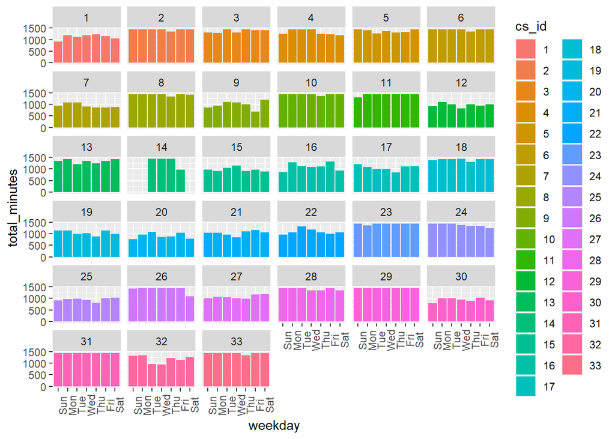

```r
# Average minutes recorded each weekday, by id
df_daily %>%
  mutate(weekday = wday(date, label=TRUE)) %>%
  mutate(total_minutes = very_active_minutes+fairly_active_minutes+lightly_active_minutes+sedentary_minutes) %>%
  group_by(cs_id, weekday) %>%
  summarise(total_minutes = mean(total_minutes)) %>%
  ggplot(aes(x=weekday, y=total_minutes, fill=cs_id)) + geom_col() + facet_wrap(~cs_id) + scale_fill_discrete() + theme(axis.text.x = element_text(angle=90))
```

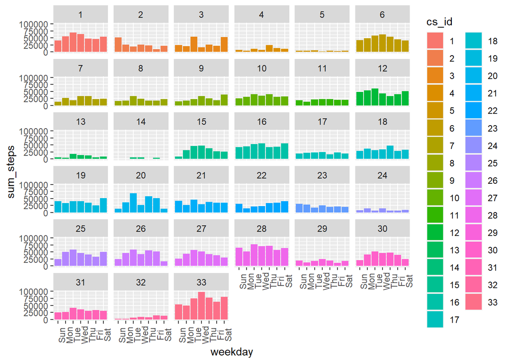

```r
# Total steps recorded each weekday, by id
df_daily %>%
  mutate(weekday = wday(date, label=TRUE)) %>%
  group_by(cs_id, weekday) %>%
  summarise(sum_steps = sum(total_steps)) %>%
  ggplot(aes(x=weekday, y=sum_steps, fill=cs_id)) + geom_col() +
  facet_wrap(~cs_id) + scale_fill_discrete() + theme(axis.text.x = element_text(angle=90))
```

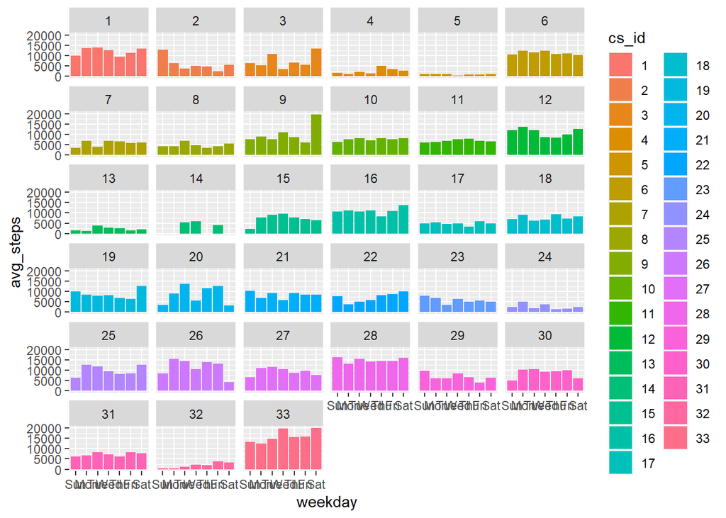

```r
# Average steps recorded each weekday, by id
df_daily %>%
  mutate(weekday = wday(date, label=TRUE)) %>%
  group_by(cs_id, weekday) %>%
  summarise(avg_steps = mean(total_steps)) %>%
  ggplot(aes(x=weekday, y=avg_steps, fill=cs_id)) + geom_col() + facet_wrap(~cs_id) + scale_fill_discrete()
```

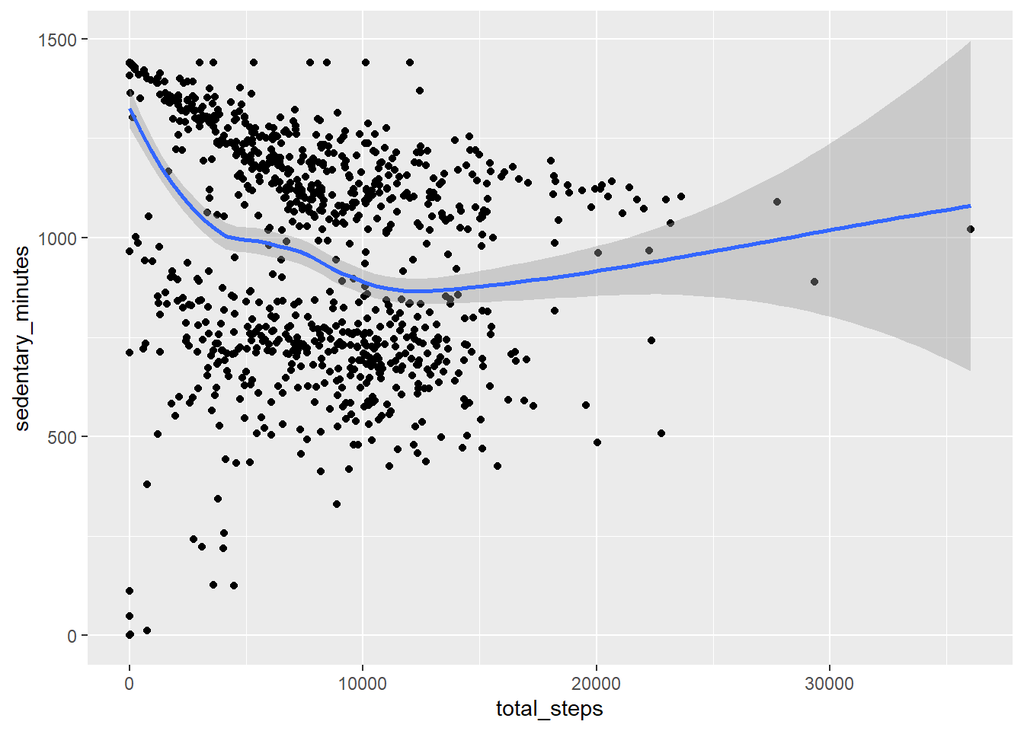

```r
# Scatter plot of steps to sedentary minutes
df_daily %>%
  ggplot(aes(x=total_steps, y=sedentary_minutes)) + geom_point() + scale_color_discrete() + geom_smooth()
```

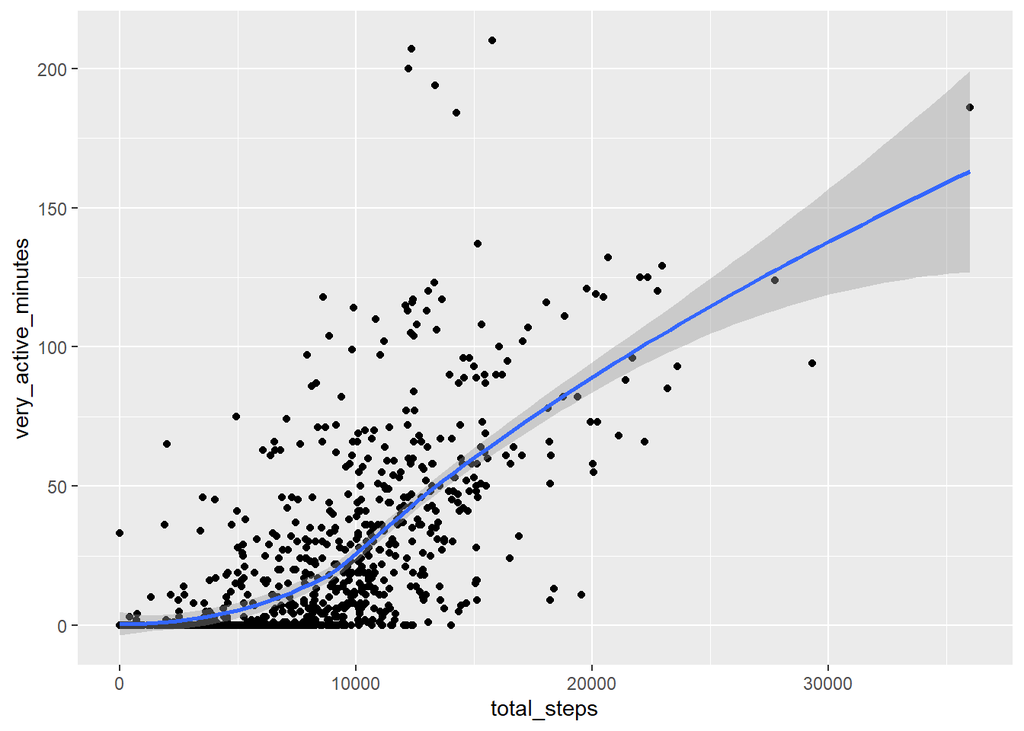

```r
# Scatter plot of steps to very active minutes
df_daily %>%
  ggplot(aes(x=total_steps, y=very_active_minutes)) + geom_point() + scale_color_discrete() + geom_smooth()
```

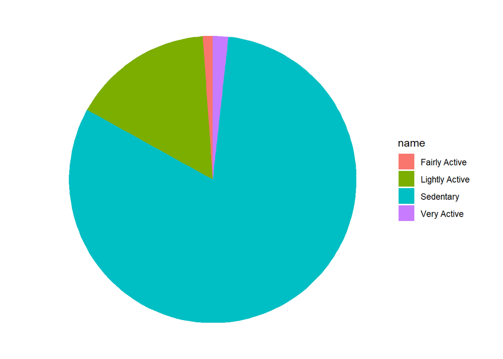

```r
# Pie plot of activity levels for all ids
df_daily %>%
  summarise('Very Active'=sum(very_active_minutes), 'Fairly Active'=sum(fairly_active_minutes),'Lightly Active'=sum(lightly_active_minutes),'Sedentary'=sum(sedentary_minutes)) %>%
  pivot_longer(cols=names(.)) %>%
  ggplot(aes(x="", y=value, fill=name)) + geom_bar(stat='identity', width=1) + coord_polar("y", start=0) + theme_void() + scale_fill_discrete()
```

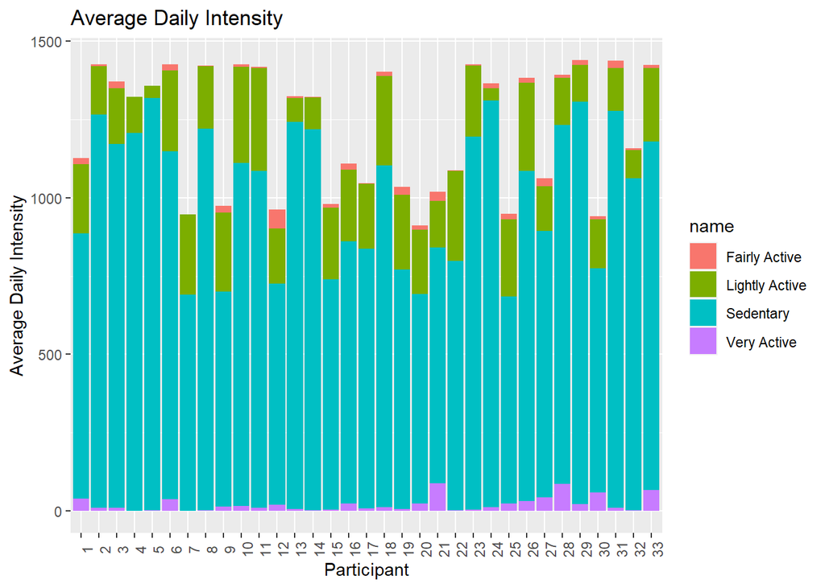

```r
# average daily intensity, by id
df_daily %>%
  group_by(cs_id) %>%
  summarise('Very Active' = mean(very_active_minutes), 'Fairly Active' = mean(fairly_active_minutes), 'Lightly Active' = mean(lightly_active_minutes), 'Sedentary' = mean(sedentary_minutes)) %>%
  pivot_longer(cols='Very Active':'Sedentary') %>%
  ggplot(aes(x=cs_id, y=value, fill=name)) + geom_bar(stat='identity') + labs(title="Average Daily Intensity", x="Participant", y="Average Daily Intensity") + theme(axis.text.x = element_text(angle=90))
```

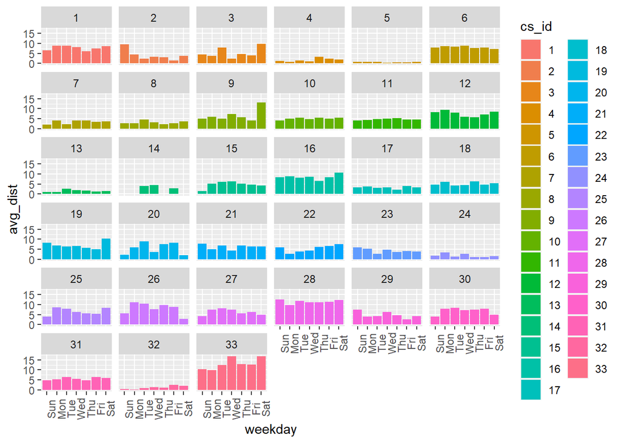

```r
# average distance by weekday, by id
df_daily %>%
  mutate(weekday = wday(date, label=TRUE)) %>%
  group_by(cs_id, weekday) %>%
  summarise(avg_dist = mean(total_distance)) %>%
  ggplot(aes(x=weekday, y=avg_dist, fill=cs_id)) + geom_col() + facet_wrap(~cs_id) + scale_fill_discrete() + theme(axis.text.x = element_text(angle=90))
```

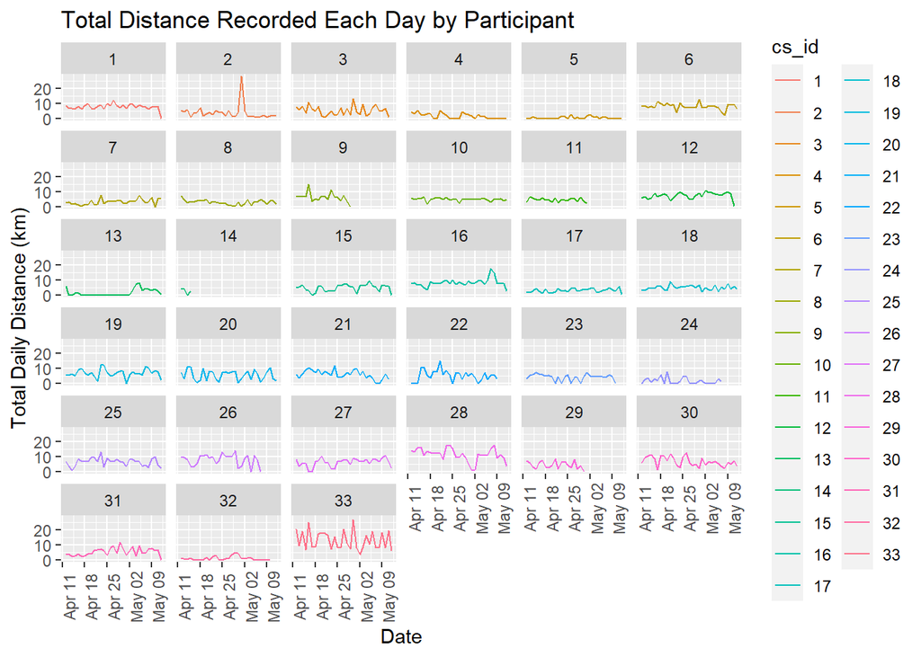

```r
# total distance each day, by id
df_daily %>%
  ggplot(aes(x=date, y=total_distance, color=cs_id)) + geom_line() + facet_wrap(~cs_id) + scale_color_discrete() + theme(axis.text.x = element_text(angle=90)) + labs(title="Total Distance Recorded Each Day by Participant") + xlab("Date") + ylab("Total Daily Distance (km)")
```

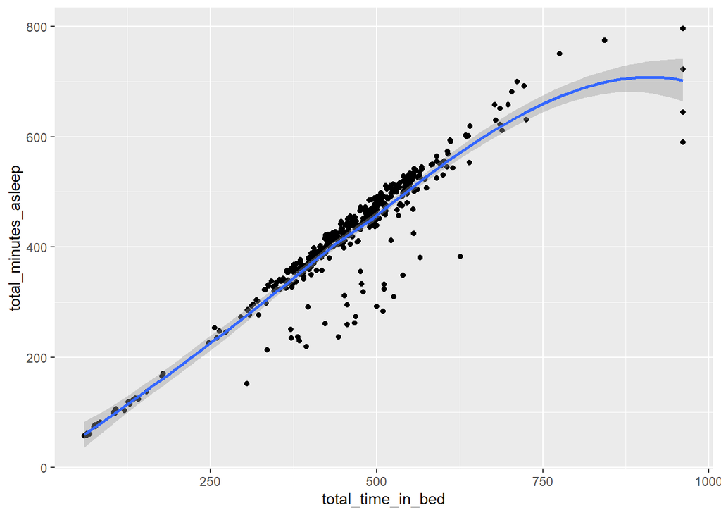

```r
# scatter plot total time in bed vs total minutes asleep
df_sleep_daily %>%
  ggplot(aes(x=total_time_in_bed, y=total_minutes_asleep)) + geom_point() + geom_smooth()
```

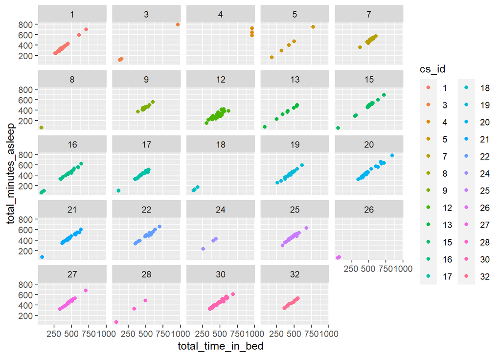

```r
# time in bed vs minutes asleep, by id
df_sleep_daily %>%
  ggplot(aes(x=total_time_in_bed, y=total_minutes_asleep, color=cs_id)) + geom_point() + facet_wrap(~cs_id) + scale_color_discrete()
```

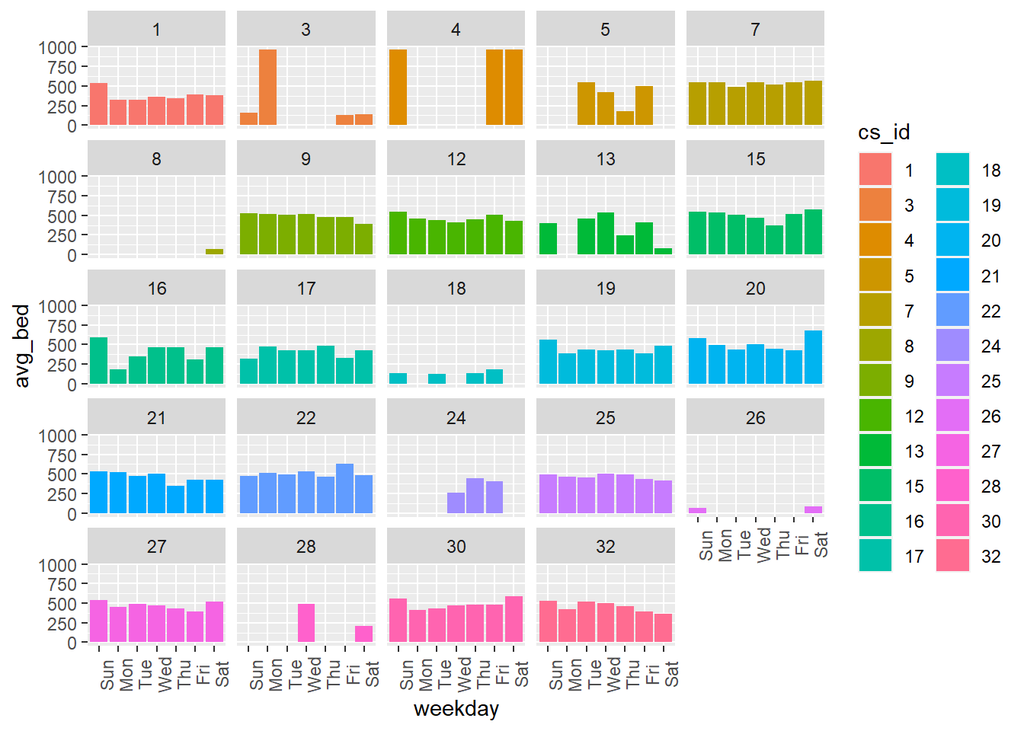

```r
# average time in bed by weekday, by id
df_sleep_daily %>%
  mutate(weekday = wday(date, label=TRUE)) %>%
  group_by(cs_id, weekday) %>%
  summarise(avg_bed = mean(total_time_in_bed)) %>%
  ggplot(aes(x=weekday, y=avg_bed, fill=cs_id)) + geom_col() + facet_wrap(~cs_id) + scale_fill_discrete()+ theme(axis.text.x = element_text(angle=90))
```

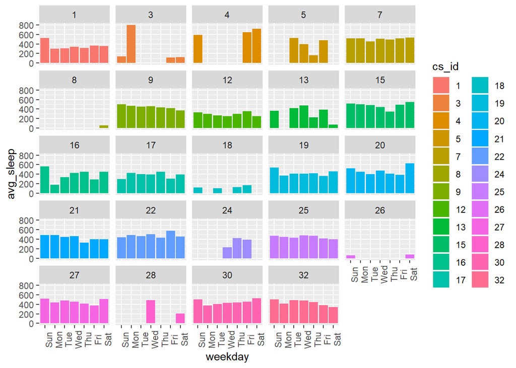

```r
# average time asleep by weekday, by id
df_sleep_daily %>%
  mutate(weekday = wday(date, label=TRUE)) %>%
  group_by(cs_id, weekday) %>%
  summarise(avg_sleep = mean(total_minutes_asleep)) %>%
  ggplot(aes(x=weekday, y=avg_sleep, fill=cs_id)) + geom_col() + facet_wrap(~cs_id) + scale_fill_discrete()+ theme(axis.text.x = element_text(angle=90))
```

## Analyze Hourly Data

### Inspect and Summarize Hourly Data

```r
str(df_hourly)
```

```
## spc_tbl_ [22,099 × 9] (S3: spec_tbl_df/tbl_df/tbl/data.frame)
##  $ id               : chr [1:22099] "1503960366" "1503960366" "1503960366" "1503960366" ...
##  $ date_time        : POSIXct[1:22099], format: "2016-04-12 00:00:00" "2016-04-12 01:00:00" ...
##  $ date             : Date[1:22099], format: "2016-04-12" "2016-04-12" ...
##  $ weekday          : chr [1:22099] "Tuesday" "Tuesday" "Tuesday" "Tuesday" ...
##  $ calories         : num [1:22099] 81 61 59 47 48 48 48 47 68 141 ...
##  $ total_intensity  : num [1:22099] 20 8 7 0 0 0 0 0 13 30 ...
##  $ average_intensity: num [1:22099] 0.333 0.133 0.117 0 0 ...
##  $ step_total       : num [1:22099] 373 160 151 0 0 ...
##  $ cs_id            : Ord.factor w/ 33 levels "1"<"2"<"3"<"4"<..: 1 1 1 1 1 1 1 1 1 1 ...
##  - attr(*, "spec")=
##   .. cols(
##   ..   id = col_character(),
##   ..   date_time = col_datetime(format = "%Y-%m-%d %H:%M:%S"),
##   ..   date = col_date(format = "%Y-%m-%d"),
##   ..   weekday = col_character(),
##   ..   calories = col_double(),
##   ..   total_intensity = col_double(),
##   ..   average_intensity = col_double(),
##   ..   step_total = col_double(),
##   ..   cs_id = col_double()
##   .. )
##  - attr(*, "problems")=<externalptr>
```

```r
summary(df_hourly)
```

```
##       id              date_time                           date
##  Length:22099       Min.   :2016-04-12 00:00:00.00   Min.   :2016-04-12
##  Class :character   1st Qu.:2016-04-19 01:00:00.00   1st Qu.:2016-04-19
##  Mode  :character   Median :2016-04-26 06:00:00.00   Median :2016-04-26
##                     Mean   :2016-04-26 11:46:42.58   Mean   :2016-04-26
##                     3rd Qu.:2016-05-03 19:00:00.00   3rd Qu.:2016-05-03
##                     Max.   :2016-05-12 15:00:00.00   Max.   :2016-05-12
##
##    weekday             calories      total_intensity  average_intensity
##  Length:22099       Min.   : 42.00   Min.   :  0.00   Min.   :0.0000
##  Class :character   1st Qu.: 63.00   1st Qu.:  0.00   1st Qu.:0.0000
##  Mode  :character   Median : 83.00   Median :  3.00   Median :0.0500
##                     Mean   : 97.39   Mean   : 12.04   Mean   :0.2006
##                     3rd Qu.:108.00   3rd Qu.: 16.00   3rd Qu.:0.2667
##                     Max.   :948.00   Max.   :180.00   Max.   :3.0000
##
##    step_total          cs_id
##  Min.   :    0.0   2      :  736
##  1st Qu.:    0.0   5      :  736
##  Median :   40.0   6      :  736
##  Mean   :  320.2   7      :  736
##  3rd Qu.:  357.0   10     :  736
##  Max.   :10554.0   18     :  736
##                    (Other):17683
```

### Plot Hourly Data

Intensity values are summarizations of by-the-minute activity level records. For example, as will be seen in the df_minutes data frame, the smart device labeled each minute as Very Active/Fairly Active/Lightly Active/Sedentary from 3 to 0 based on proprietary algorithms. The total_intensity field sums all of the individual minutes’ activity level (0-3). The average intensity field divides the total_intensity field by 60 (minutes) to determine the average activity level throughout the hour.

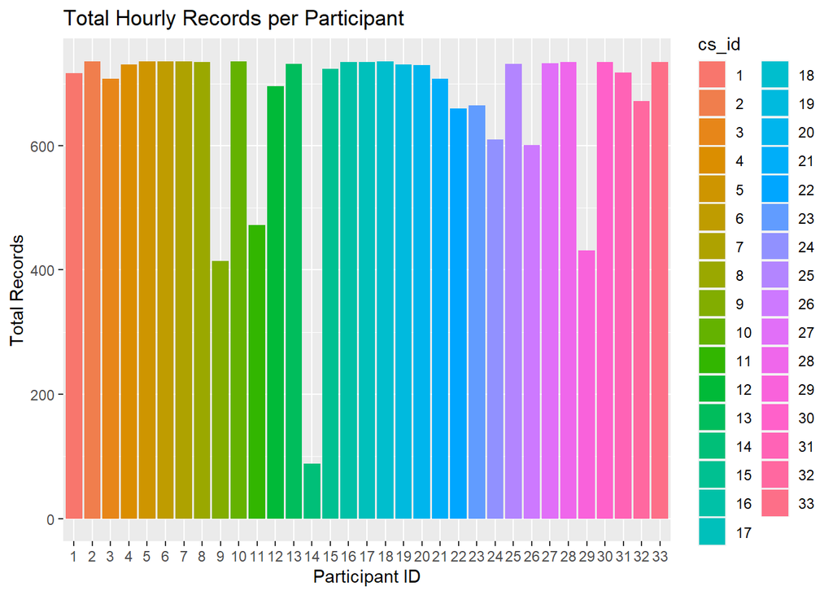

```r
# Total records by id
df_hourly %>%
  group_by(cs_id) %>%
  summarise(total_records = n()) %>%
  ggplot(aes(x=cs_id, y=total_records, fill=cs_id)) + geom_col() + scale_fill_discrete() + labs(title='Total Hourly Records per Participant', x='Participant ID', y='Total Records')
```

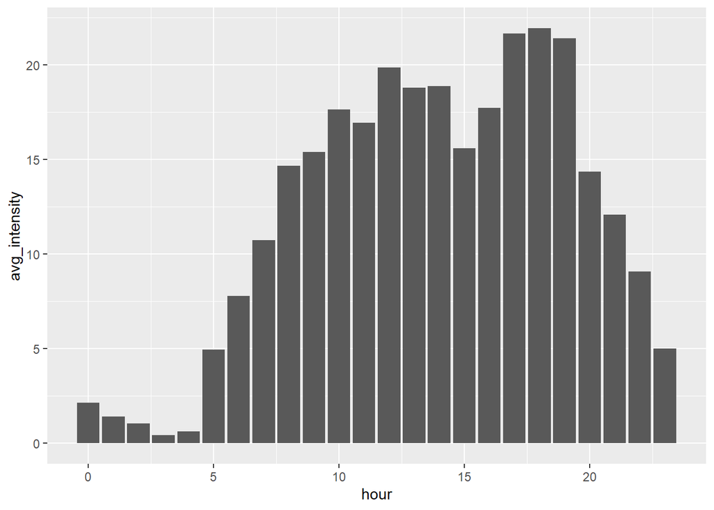

```r
# average hourly total intensity across all ids
df_hourly %>%
  mutate(hour = hour(date_time)) %>%
  group_by(hour) %>%
  summarise(avg_intensity = mean(total_intensity)) %>%
  ggplot(aes(x=hour, y=avg_intensity)) + geom_col() + scale_fill_discrete()
```

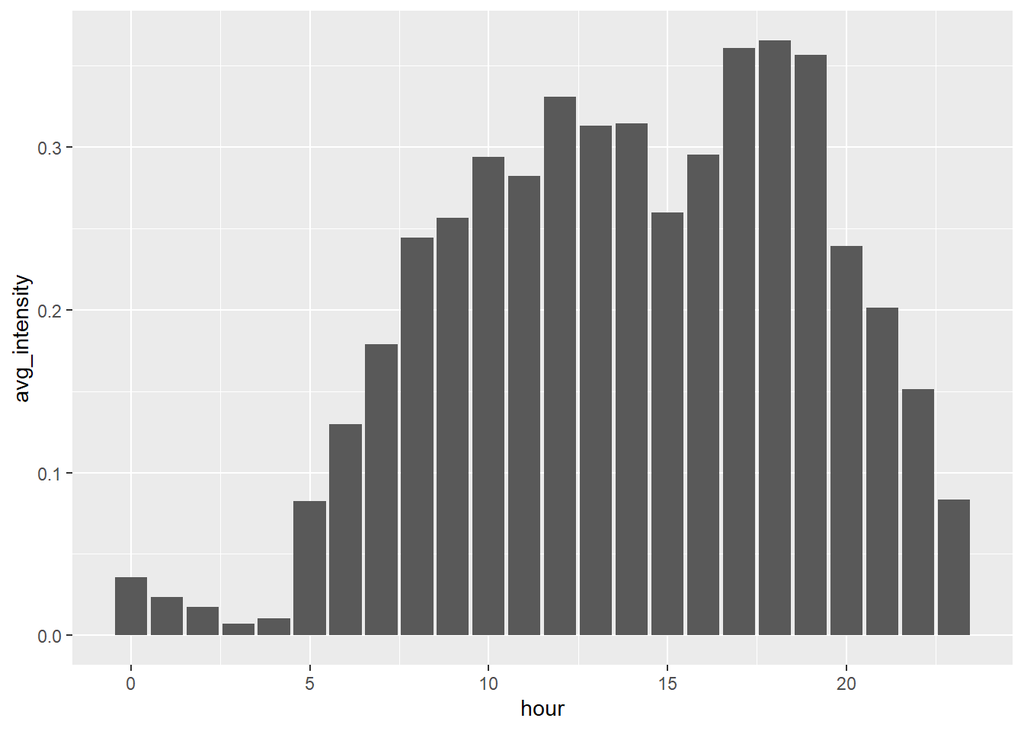

```r
# average hourly intensity across all ids
df_hourly %>%
  mutate(hour = hour(date_time)) %>%
  group_by(hour) %>%
  summarise(avg_intensity = mean(average_intensity)) %>%
  ggplot(aes(x=hour, y=avg_intensity)) + geom_col() + scale_fill_discrete()
```

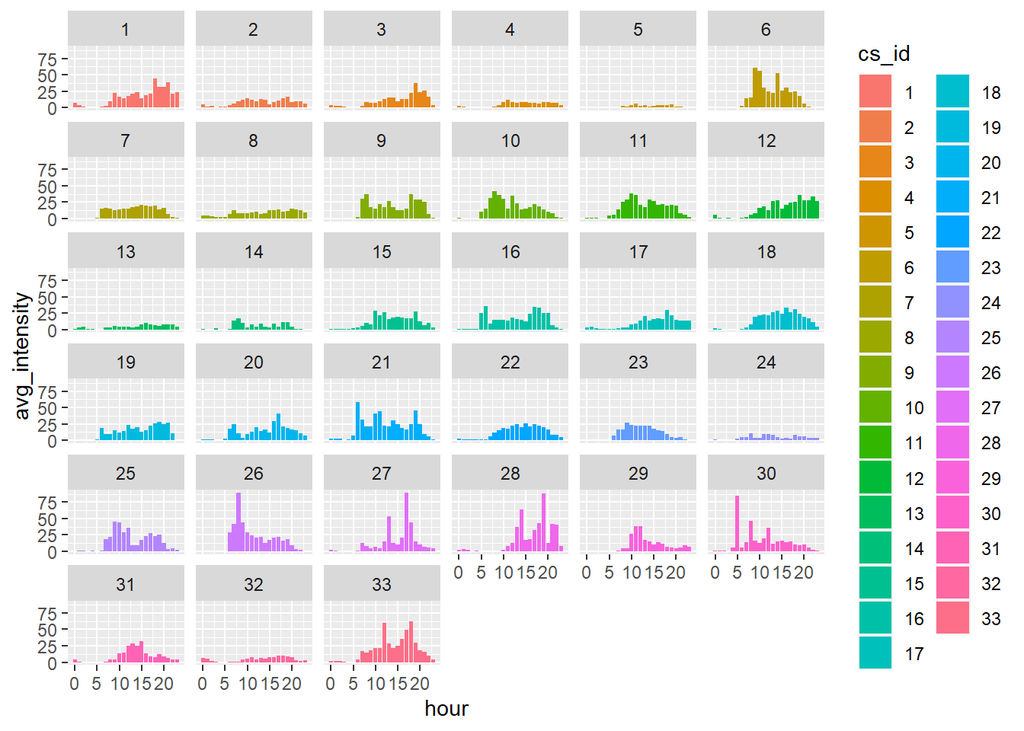

```r
# average hourly total intensity, by id
df_hourly %>%
  mutate(hour = hour(date_time)) %>%
  group_by(cs_id, hour) %>%
  summarise(avg_intensity = mean(total_intensity)) %>%
  ggplot(aes(x=hour, y=avg_intensity, fill=cs_id)) + geom_col() + facet_wrap(~cs_id) + scale_fill_discrete()
```

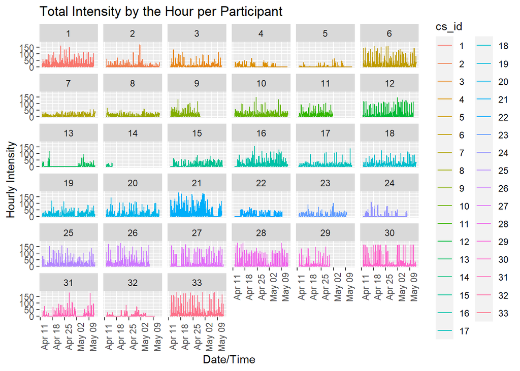

```r
# total intensity value by the hour, by id
df_hourly %>%
  ggplot(aes(x=date_time, y=total_intensity, color=cs_id)) + geom_line() + facet_wrap(~cs_id) + scale_color_discrete() + theme(axis.text.x = element_text(angle=90)) + labs(title='Total Intensity by the Hour per Participant', x='Date/Time', y='Hourly Intensity')
```

## Analyze Minutes Data

### Inspect and Summarize Minutes Data

```r
str(df_minutes)
```

```
## spc_tbl_ [1,325,580 × 7] (S3: spec_tbl_df/tbl_df/tbl/data.frame)
##  $ id       : chr [1:1325580] "1503960366" "1503960366" "1503960366" "1503960366" ...
##  $ date_time: POSIXct[1:1325580], format: "2016-04-12 00:00:00" "2016-04-12 00:01:00" ...
##  $ calories : num [1:1325580] 0.786 0.786 0.786 0.786 0.786 ...
##  $ intensity: num [1:1325580] 0 0 0 0 0 0 0 0 0 0 ...
##  $ me_ts    : num [1:1325580] 10 10 10 10 10 12 12 12 12 12 ...
##  $ steps    : num [1:1325580] 0 0 0 0 0 0 0 0 0 0 ...
##  $ cs_id    : Ord.factor w/ 33 levels "1"<"2"<"3"<"4"<..: 1 1 1 1 1 1 1 1 1 1 ...
##  - attr(*, "spec")=
##   .. cols(
##   ..   id = col_character(),
##   ..   date_time = col_datetime(format = "%Y-%m-%d %H:%M:%S"),
##   ..   calories = col_double(),
##   ..   intensity = col_double(),
##   ..   me_ts = col_double(),
##   ..   steps = col_double(),
##   ..   cs_id = col_double()
##   .. )
##  - attr(*, "problems")=<externalptr>
```

```r
summary(df_minutes)
```

```
##       id              date_time                         calories
##  Length:1325580     Min.   :2016-04-12 00:00:00.00   Min.   : 0.0000
##  Class :character   1st Qu.:2016-04-19 01:51:00.00   1st Qu.: 0.9357
##  Mode  :character   Median :2016-04-26 06:27:00.00   Median : 1.2176
##                     Mean   :2016-04-26 12:09:55.15   Mean   : 1.6231
##                     3rd Qu.:2016-05-03 18:55:00.00   3rd Qu.: 1.4327
##                     Max.   :2016-05-12 15:59:00.00   Max.   :19.7499
##
##    intensity          me_ts            steps             cs_id
##  Min.   :0.0000   Min.   :  0.00   Min.   :  0.000   2      :  44160
##  1st Qu.:0.0000   1st Qu.: 10.00   1st Qu.:  0.000   5      :  44160
##  Median :0.0000   Median : 10.00   Median :  0.000   7      :  44160
##  Mean   :0.2006   Mean   : 14.69   Mean   :  5.336   10     :  44160
##  3rd Qu.:0.0000   3rd Qu.: 11.00   3rd Qu.:  0.000   18     :  44160
##  Max.   :3.0000   Max.   :157.00   Max.   :220.000   6      :  44100
##                                                      (Other):1060680
```

### Plot Minutes Data

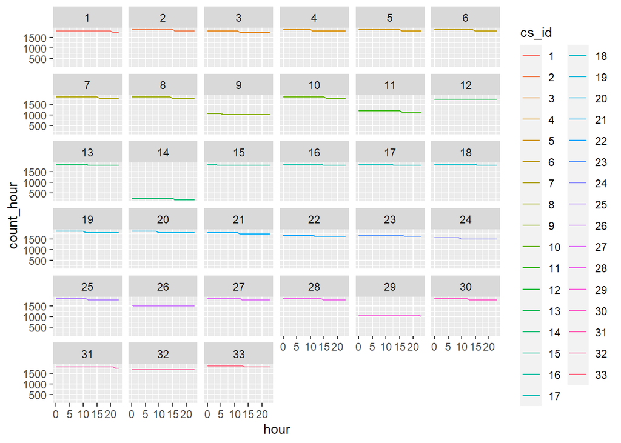

```r
# average recordings by the hour
df_minutes %>%
  mutate(hour = hour(date_time)) %>%
  group_by(cs_id, hour) %>%
  summarise(count_hour = n()) %>%
  ggplot(aes(x=hour, y=count_hour, color=cs_id)) + geom_line() + facet_wrap(~cs_id) + scale_color_discrete()
```

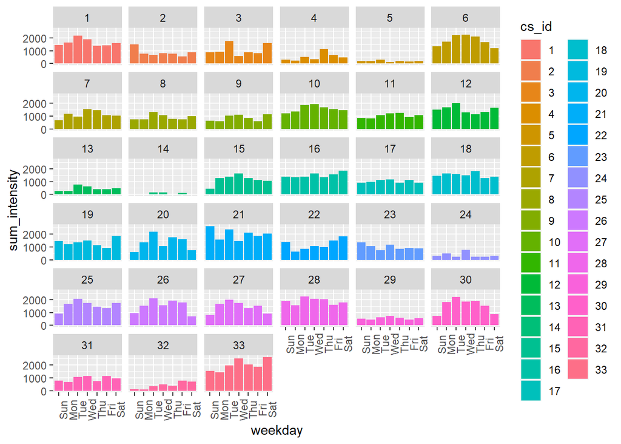

```r
# total active (>0/not sedentary) intensity recorded by weekday, per id
df_minutes %>%
  filter(intensity > 0) %>%
  mutate(weekday = wday(date_time, label=TRUE)) %>%
  group_by(cs_id, weekday) %>%
  summarise(sum_intensity = sum(intensity)) %>%
  ggplot(aes(x=weekday, y=sum_intensity, fill=cs_id)) + geom_col() + facet_wrap(~cs_id) + scale_fill_discrete() + theme(axis.text.x = element_text(angle=90))
```

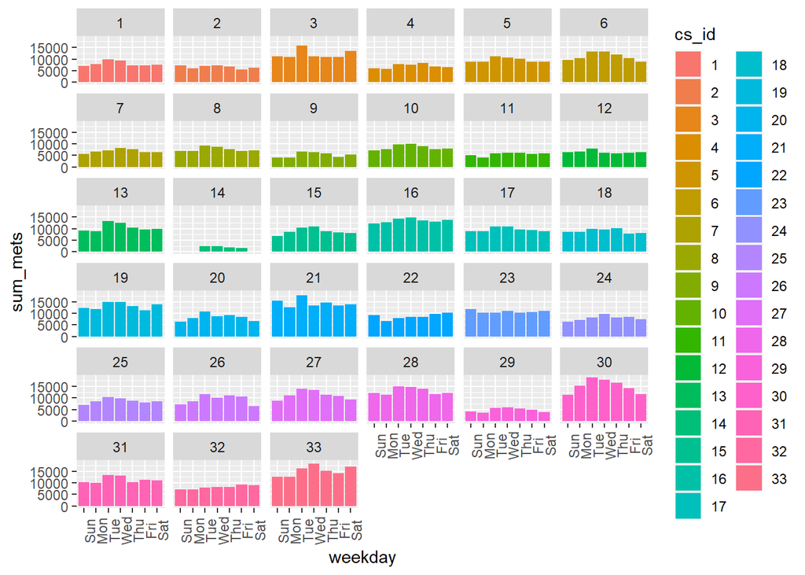

```r
# total calories burned by weekday, per id
df_minutes %>%
  mutate(weekday = wday(date_time, label=TRUE)) %>%
  group_by(cs_id, weekday) %>%
  summarise(sum_mets = sum(calories)) %>%
  ggplot(aes(x=weekday, y=sum_mets, fill=cs_id)) + geom_col() + facet_wrap(~cs_id) + scale_fill_discrete() + theme(axis.text.x = element_text(angle=90))
```

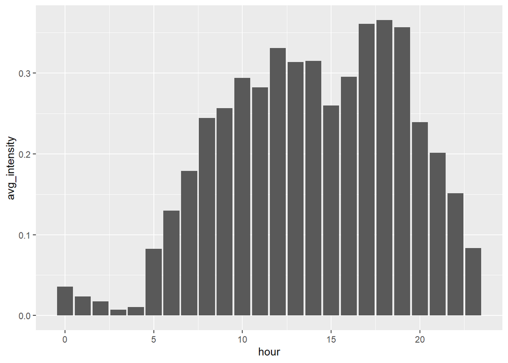

```r
# average intensity by the hour per all ids
df_minutes %>%
  mutate(hour = hour(date_time)) %>%
  group_by(hour) %>%
  summarise(avg_intensity = mean(intensity)) %>%
  ggplot(aes(x=hour, y=avg_intensity)) + geom_col()
```

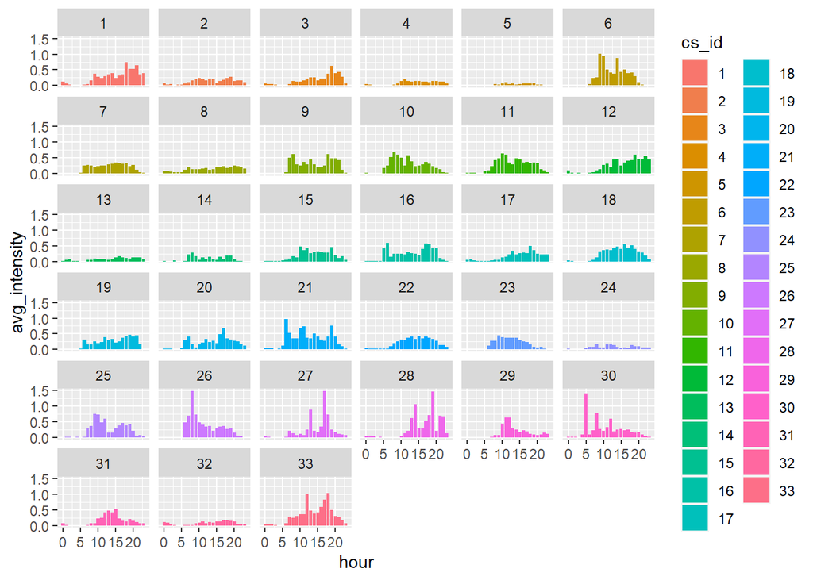

```r
# average intensity by the hour, by id
df_minutes %>%
  mutate(hour = hour(date_time)) %>%
  group_by(cs_id, hour) %>%
  summarise(avg_intensity = mean(intensity)) %>%
  ggplot(aes(x=hour, y=avg_intensity, fill=cs_id)) + geom_col() + facet_wrap(~cs_id) + scale_fill_discrete()
```

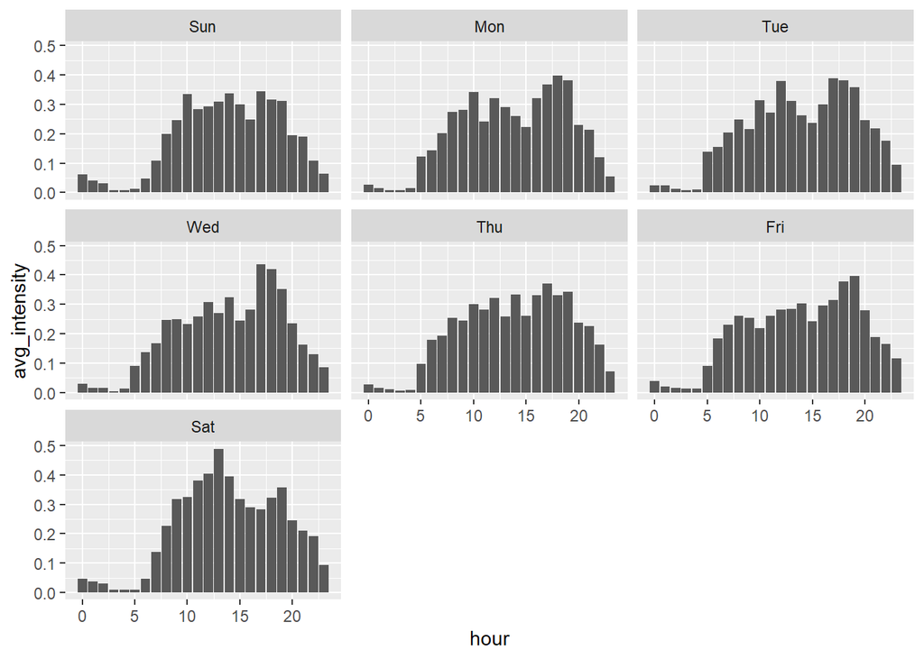

```r
# average intensity by the weekday and hour
df_minutes %>%
  mutate(hour = hour(date_time), weekday = wday(date_time, label=TRUE)) %>%
  group_by(weekday, hour) %>%
  summarise(avg_intensity = mean(intensity)) %>%
  ggplot(aes(x=hour, y=avg_intensity)) + geom_col() + facet_wrap(~weekday)
```

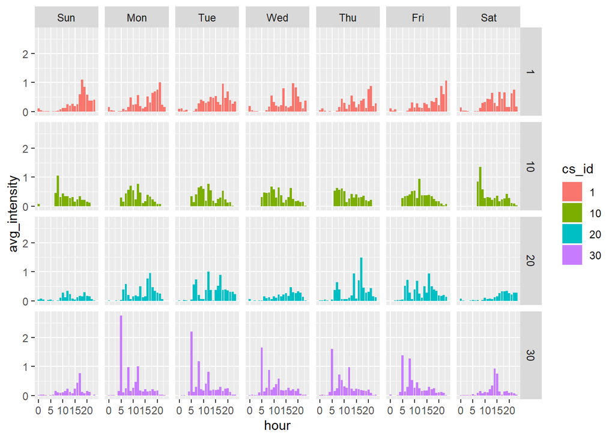

```r
# average intensity by the weekday and hour, per id
# we will look at just a few ids due to poor rendering if we do all at once
df_minutes %>%
  filter(cs_id == '1'|cs_id == '10'|cs_id == '20'|cs_id == '30') %>%
  mutate(hour = hour(date_time), weekday = wday(date_time, label=TRUE)) %>%
  group_by(cs_id, weekday, hour) %>%
  summarise(avg_intensity = mean(intensity)) %>%
  ggplot(aes(x=hour, y=avg_intensity, fill=cs_id)) + geom_col() + scale_fill_discrete() + facet_grid(cs_id ~ weekday)
```

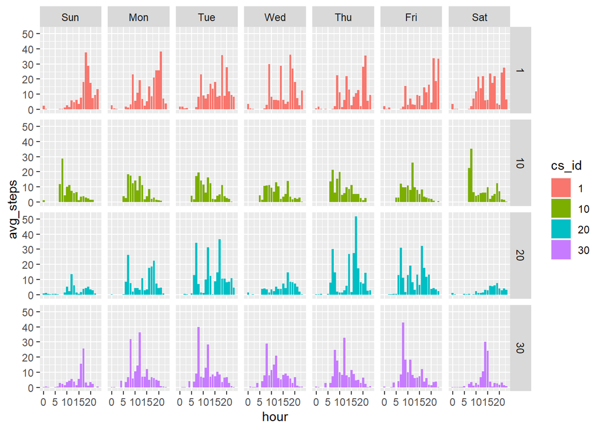

```r
# average steps by the weekday and hour, per id
# we will look at just a few ids due to poor rendering if we do all at once
df_minutes %>%
  filter(cs_id == '1'|cs_id == '10'|cs_id == '20'|cs_id == '30') %>%
  mutate(hour = hour(date_time), weekday = wday(date_time, label=TRUE)) %>%
  group_by(cs_id, weekday, hour) %>%
  summarise(avg_steps = mean(steps)) %>%
  ggplot(aes(x=hour, y=avg_steps, fill=cs_id)) + geom_col() + scale_fill_discrete() + facet_grid(cs_id ~ weekday)
```